# DS105-07-03-04 - Example ANCOVA.nb

# Load Libraries

There are several libraries you will need to load in order to complete the ANCOVA process.

- `rcompanion`, as you know by now, is for assessing normality with easy, best-fit histograms.
- The `car` library is both for assessing homogeneity of variance and for dealing with violations of said assumption.
- The `effects` library will assist you in the creation of means adjusted by your covariate,
- and the `multcomp` package is for conducting post hocs for ANCOVAs.

```r
# install.packages("effects")
# install.packages("multcomp")
library("rcompanion")
library("car")
library("effects")
library("multcomp")
```

# Load in Data

```r
graduate_admissions <- read.csv("./data/graduate_admissions.csv")

  # View data
    head(graduate_admissions)
```

|  | Serial.No. | GRE.Score | TOEFL.Score | University.Rating | SOP | LOR | CGPA | Research | Chance.of.Admit |
| --- | --- | --- | --- | --- | --- | --- | --- | --- | --- |
| 1 | 1 | 337 | 118 | 4 | 4.5 | 4.5 | 9.65 | 1 | 0.92 |
| 2 | 2 | 324 | 107 | 4 | 4.0 | 4.5 | 8.87 | 1 | 0.76 |
| 3 | 3 | 316 | 104 | 3 | 3.0 | 3.5 | 8.00 | 1 | 0.72 |
| 4 | 4 | 322 | 110 | 3 | 3.5 | 2.5 | 8.67 | 1 | 0.80 |
| 5 | 5 | 314 | 103 | 2 | 2.0 | 3.0 | 8.21 | 0 | 0.65 |
| 6 | 6 | 330 | 115 | 5 | 4.5 | 3.0 | 9.34 | 1 | 0.90 |

# Question Setup

You will answer the following question with your ANCOVA:

`Controlling for students' research participation in undergrad, does the rating of the students' undergraduate university impact their chance of admittance into graduate school?`

For this question, the covariate is students’ research participation in undergrad (`Research`), since that is what you are controlling. The IV is the categorical variable, rated 1-5, of students’ undergraduate university (`University.Rating`), and the DV is the chance of admittance into graduate school (`Chance.of.Admit`).

# Data Wrangling

With this particular dataset, there is very little data wrangling required. All that is necessary is to ensure that all categorical variables are factors, not integers, since the data type will throw off the code for getting adjusted means and post hocs later (the ANCOVA itself will take the data in any data type).

### **Ensure the IV (Independent Variable) is a Factor**

You can see what format the data is in for your IV by using the `str()` function:

```r
str(graduate_admissions$University.Rating)
```

```
 int [1:400] 4 4 3 3 2 5 3 2 1 3 ...
```

Note that the output shows it is an integer! That can easily be converted:

```r
graduate_admissions$University.Rating <- as.factor(graduate_admissions$University.Rating)
```

### **Ensure the CV (CoVariate) is a Factor**

Covariates can either be categorical or continuous. Either is perfectly acceptable. However, if you do use a categorical CV, like `Research` is, it needs to be formatted as factor data, not as an integer. You can test and fix this just like the IV:

```r
str(graduate_admissions$Research)
```

```
 int [1:400] 1 1 1 1 0 1 1 0 0 0 ...
```

```r
graduate_admissions$Research <- as.factor(graduate_admissions$Research)
```

You have now completed all data wrangling activities for this particular ANCOVA!

# Testing Assumptions

The assumptions for an ANCOVA are similar to those for your basic ANOVAs.

However, one assumption is added - the assumption of *homogeneity of regression slopes*, which tests for whether the predictor variable (DV) and the covariate are independent of each other.

This is because you are controlling for the presence of the covariate, not determining whether it has an effect on your DV. If the covariate is related in any way to your DV, then most likely it should be an independent variable, not a covariate, because it is explaining some variance in your model.

### Normality

Is this one starting to get old hat yet? Take a look at the normality of your continuous variable, `Chance.of.Admit`.

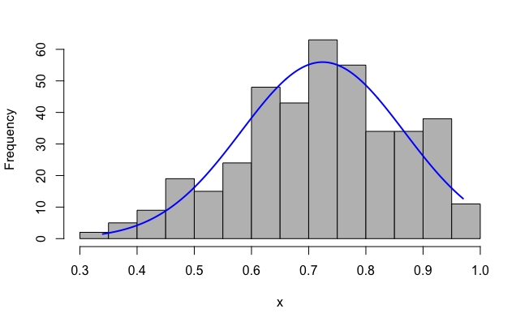

```r
plotNormalHistogram(graduate_admissions$Chance.of.Admit)
```

It could probably be a little more normal, though it’s not too bad. Try a **square transformation**:

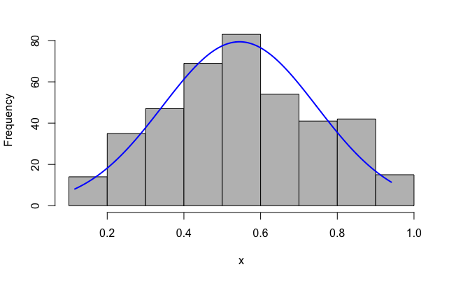

```r
graduate_admissions$Chance.of.AdmitSQ <- graduate_admissions$Chance.of.Admit * graduate_admissions$Chance.of.Admit

  # Plot after transformation
    plotNormalHistogram(graduate_admissions$Chance.of.AdmitSQ)
```

It looks like that was a pretty good choice, huh?

**Meets the assumption of normality (after transformation).**

### **Homogeneity of Variance**

To test for homogeneity of variance, you will run Levene’s Test. Unfortunately, however, Levene’s test will not take into account any categorical covariates (though they are perfectly valid). So you’ll include the model as best you can without it:

```r
leveneTest(Chance.of.AdmitSQ~University.Rating, data=graduate_admissions)
```

```
Levene's Test for Homogeneity of Variance (center = median)
       Df F value  Pr(>F)
group   4  2.4283 0.04734 *
      395
---
Signif. codes:  0 ‘***’ 0.001 ‘**’ 0.01 ‘*’ 0.05 ‘.’ 0.1 ‘ ’ 1
```

**Unfortunately, this test is significant, which means that you have violated the assumption of homogeneity of variance.** You will learn how to correct for this violation on the next page.

*p < .05* –> Unfortunately, this test is significant, which means that you have violated the assumption of homogeneity of variance.

### **Homogeneity of Regression Slopes**

In order to test for homogeneity of regression slopes, you can run a one-way ANOVA, with your covariate as the IV and the DV you were planning to use for your ANCOVA. If the *F* test is non-significant, then you are good to go!

Here is the basic ANOVA information:

```r
Homogeneity_RegrSlp = lm(Chance.of.AdmitSQ~Research, data=graduate_admissions)
anova(Homogeneity_RegrSlp)
```

```
Analysis of Variance Table

Response: Chance.of.AdmitSQ
           Df  Sum Sq Mean Sq F value    Pr(>F)
Research    1  5.2035  5.2035   189.8 < 2.2e-16 ***
Residuals 398 10.9113  0.0274
---
Signif. codes:  0 ‘***’ 0.001 ‘**’ 0.01 ‘*’ 0.05 ‘.’ 0.1 ‘ ’ 1
```

As you can see, the results of this ANOVA are saved into an object called `Homogeneity_RegrSlp`. Then you can use the `lm()` function to create your linear model. The dependent variable will remain the same as the one you plan to use in your ANCOVA - `Chance.of.AdmitSQ`. And the covariate you’re planning to use in the ANCOVA will be the IV - `Research`. Specify the dataset with the argument `data=` and away you run! To get an ANOVA summary table out of this analysis, just call the `anova` function on your saved object.

Unfortunately, since the *p* **value is significant, your data does not meet the assumption of homogeneity of regression slopes.** That means that whether someone does research or not actually does have an impact on their chance of admittance to graduate school, and that you should NOT use `Research` as a covariate, but rather include it as a second independent variable in the model. However, for the purposes of learning, you will just continue on.

Unfortunately, since the *p* **value is significant, your data does not meet the assumption of homogeneity of regression slopes.**

### Sample Size

The last assumption for ANCOVAs is sample size. There has to be at least 20 cases for every IV or CV. Since you will have one IV and one CV, you will need at least 40 rows of data. In this case, you have 400 cases, so this assumption is more than adequately met!

**Meets the assumption of sample size.**

# Running the Analysis

You will run an ANCOVA using the same linear model format that you have used for regressions, but playing with the model terms some. Here is the initial code needed for your ANCOVA.

The `lm()` function specifies that this is a linear model.

Then you’ll input your y variable, or DV, first. In this case, since you are predicting a student’s chance of admission into graduate school, your DV is `Chance.of.Admit`.

What follows immediately after the tilde is a mash-up of things. There are a couple important things to note:

1. The covariate(s) ALWAYS has to come first!! This is because the variables are taken in order in this case, and you want the effects of the covariate to be parsed out first.
2. The plus sign adds in additional covariates or independent variables.
3. The asterisk creates what is called an *interaction term*. It looks at the effects of one thing BY another thing. Sometimes, you will find effects when looking at an interaction term that were invisible even if you had both variables together in the model, so it’s typically a best practice to always include an interaction term if you are going to have more than one IV or CV in your model (basically, anything that is not a one-way ANOVA).

So this model is looking at the chance of admittance to graduate school, holding whether students have done research constant, by University Rating, and examining how University Rating interacts with Research. It’s possible, for instance, that only when a school is rated very well or very poorly that it impacts whether students’ research matters.

Once you have all your terms in place, you can call the ANCOVA with the `anova()` function, where you put the name of your model in as an argument.

```r
ANCOVA = lm(Chance.of.Admit~Research + University.Rating*Research, data=graduate_admissions)

anova(ANCOVA)
```

```
Analysis of Variance Table

Response: Chance.of.Admit
                            Df Sum Sq Mean Sq  F value    Pr(>F)
Research                     1 2.4833 2.48334 293.2812 < 2.2e-16 ***
University.Rating            4 2.1884 0.54709  64.6107 < 2.2e-16 ***
Research:University.Rating   4 0.1406 0.03516   4.1523  0.002634 **
Residuals                  390 3.3023 0.00847
---
Signif. codes:  0 ‘***’ 0.001 ‘**’ 0.01 ‘*’ 0.05 ‘.’ 0.1 ‘ ’ 1
```

This ANCOVA table should look somewhat familiar to you, as it follows the same format as other ANOVA variations.

Looking at it, **you can see that there is a significant effect of the covariate, `Research`, and a significant effect of the independent variable, `University.Rating`, on a student’s chance of admission to graduate school.**

In addition, there is an interaction between `Research` and `University.Rating`, indicating that those things combined also form a significant pattern that predicts admission to graduate school.

### **When You’ve Failed Homogeneity of Variance**

If you failed the assumption of homogeneity of variance, not to fear! There is a quick and easy additional line you can add to the base model. Instead of running the `anova()` function, you can instead run the `Anova()` function. Catch the difference there? The function that corrects for a violation of homogeneity of variance has a capital “A,” whereas the “regular” summary function doesn’t. If it helps, think of the big “A” as standing for “assumption,” so when you’ve violated the assumption, head for that!

Here is what using the big A `Anova()` function looks like —

```r
Anova(ANCOVA, Type="I", white.adjust=TRUE)
```

```
Coefficient covariances computed by hccm()
```

```
Analysis of Deviance Table (Type II tests)

Response: Chance.of.Admit
                            Df       F    Pr(>F)
Research                     1 50.4762 5.769e-12 ***
University.Rating            4 83.3120 < 2.2e-16 ***
Research:University.Rating   4  2.9686    0.0195 *
Residuals                  390
---
Signif. codes:  0 ‘***’ 0.001 ‘**’ 0.01 ‘*’ 0.05 ‘.’ 0.1 ‘ ’ 1
```

Types of ANOVAs for `Type=` Argument:

- **Type I:** This is automatically used when you use the `aov()` function you were taught in earlier lessons. The sum of squares are taken sequentially, which means that they are calculated in the order in which they are listed in the model.
- **Type II:** This type of ANOVA examines the effects of all the main effects, but ignores any interaction effects. So it is not suitable if you have more than one IV or CV in your model and want to determine how they interact.
- **Type III:** This is used only when you want to look at only some sums of squares effects. Basically, you can examine only the effects you specify by changing the options for contrasts. You can think of *contrasts* as built-in, planned post hocs. Specifying them in advance and being specific as to what you are looking for means that you have less Type I error, but they can be a pain to use. Hence they will not be covered in this course!

Remember from previous lessons that the `white.adjust=TRUE` argument is what corrects for the violation of homogeneity of variance, so it is crucial to include.

**Everything remains significant, even after you’ve corrected for a violation of homogeneity of variance.**

# Post Hocs

But where do the differences lie? To answer those questions, you need to follow up with a post hoc. For an ANCOVA, you will still run a post hoc with the Tukey’s correction, but you will need to do so using functions from the `multcomp` package instead because you now need to handle the covariate and interaction effects. You will do this using the `glht()` function:

The independent variable will go in the second second of parentheses before the equals sign. `linfct=mcp` is standard code that you will use routinely.

```r
postHocs <- glht(ANCOVA,linfct=mcp(University.Rating = "Tukey"))
summary(postHocs)
```

```
     Simultaneous Tests for General Linear Hypotheses

Multiple Comparisons of Means: Tukey Contrasts


Fit: lm(formula = Chance.of.Admit ~ Research + University.Rating *
    Research, data = graduate_admissions)

Linear Hypotheses:
           Estimate Std. Error t value Pr(>|t|)
2 - 1 == 0  0.06939    0.02272   3.054 0.018167 *
3 - 1 == 0  0.13581    0.02323   5.846  < 1e-04 ***
4 - 1 == 0  0.15352    0.03111   4.935  < 1e-04 ***
5 - 1 == 0  0.20827    0.03823   5.448  < 1e-04 ***
3 - 2 == 0  0.06642    0.01579   4.205 0.000270 ***
4 - 2 == 0  0.08413    0.02603   3.233 0.010434 *
5 - 2 == 0  0.13888    0.03422   4.058 0.000509 ***
4 - 3 == 0  0.01771    0.02648   0.669 0.959557
5 - 3 == 0  0.07246    0.03457   2.096 0.208038
5 - 4 == 0  0.05475    0.04029   1.359 0.634963
---
Signif. codes:  0 ‘***’ 0.001 ‘**’ 0.01 ‘*’ 0.05 ‘.’ 0.1 ‘ ’ 1
(Adjusted p values reported -- single-step method)
```

Looking in the `Pr(>|t|)` column shows the *p* values associated with each of these pairwise *t*-tests.

**It looks like there was a significant difference between a university rated “1” and all other university ratings, a university rated “2” and all other university ratings, but no differences between universities rated “3,” “4,” or”5.”**

What was higher between those differences that were significant? Well, to determine that, you will need to examine the means.

# Determine Means and draw conclusions

Because you included a covariate in your model, it is important to look at adjusted means, rather than the raw means. The means are adjusted by controlling for your covariate. This may sound needlessly complicated to you, but never fear - the `effects` package makes it easy!

Just call the `effect()` function, then put your IV in quotes and specify the model that it came from. When you run the name you gave the object, you will get this output:

```r
adjMeans <- effect("University.Rating", ANCOVA)
```

```
NOTE: University.Rating is not a high-order term in the model
```

```r
adjMeans
```

```
 University.Rating effect
University.Rating
        1         2         3         4         5
0.5621155 0.6393678 0.7127907 0.7792244 0.8368238
```

However, attending a school rated a 3, 4, or 5 did not significantly improve your odds of being accepted to graduate school.

Drawing an overall conclusion from this data, you might say something like:  
**“as long as you attended a medium or better rated university for undergraduate, you have relatively good odds of being accepted to graduate school, but students who attended a poorly rated university are much less likely to be accepted, when controlling for the effects of having participated in research in undergrad.”**